# Self-compassion, post-traumatic growth, and PTSD

[Corrado Caudek](https://ccaudek.github.io/)

Last modified 2020-12-10

# Motivation

Self-compassion (SC) has been proposed as a protective factor against PTSD and a factor promoting PTG.

One limit of these studies, however, is that they have often been performed in student populations, that is, in samples in which, supposedly, PTSD and PTG are only present in mild forms, if ever.

Moreover, in recent years, the role of SC has been questioned. For example, Muris, Otgaar and Pfattheicher (2019) maintain that SC is strongly associated with (reversed) Negative Affect and that, once the negative component of SC is removed, the added value of positive SC is marginal.

Furthermore, Geiger, Pfattheicher, Hartung, Weiss, Schindler, and Wilhelm (2018) have questioned the fact that SC is a construct that does not overlap with Neuroticism. Once Neuroticism is controlled, there is no evidence of a specific contribution of SC.

The purpose of the present study is to evaluate the hypotheses of Muris et al. (2019) and of Geiger et al. (2018) in a sample of rescue workers.

# Prelims

```r
temp <- readRDS(here("data", "processed", "rescue_workers_cleaned_data.rds"))
clean_dat <- temp %>%
  dplyr::filter(age_imp > 20)
```

```r
psych::describe(clean_dat)
```

```
##                                 vars   n   mean     sd median trimmed    mad
## life_appreciation                  1 731   6.36   4.28   7.00    6.27   4.45
## new_possibilities                  2 731   8.24   6.37   8.00    7.79   7.41
## personal_strength                  3 731   9.74   5.46  10.00    9.90   5.93
## spirituality_changes               4 731   3.50   6.15   0.00    2.04   0.00
## interpersonal_relationships        5 731  13.46   9.30  13.00   13.20  11.86
## avoiding                           6 731   6.05   5.34   5.00    5.41   5.93
## intrusivity                        7 731   8.01   7.04   6.00    7.19   7.41
## iperarousal                        8 731   3.06   4.24   1.00    2.17   1.48
## social_support                     9 731  29.78   7.02  30.00   29.72   7.41
## avoiding_strategies               10 731  21.93   4.41  21.00   21.44   4.45
## positive_attitude                 11 731  33.79   4.80  34.00   33.86   4.45
## problem_orientation               12 731  33.76   5.51  34.00   33.86   5.93
## transcendent_orientation          13 731  19.20   4.07  19.00   19.03   2.97
## family                            14 731  18.53   5.24  20.00   19.23   5.93
## friends                           15 731  18.20   4.96  19.00   18.75   4.45
## significant_other                 16 731  19.48   4.93  20.00   20.27   5.93
## self_judgment                     17 731  15.23   4.61  15.00   15.29   5.93
## isolation                         18 731  13.79   4.33  14.00   13.98   4.45
## over_identification               19 731  14.63   3.86  15.00   14.88   4.45
## self_kindness                     20 731  13.69   4.28  14.00   13.63   4.45
## common_humanity                   21 731  11.48   3.33  12.00   11.43   2.97
## mindfulness                       22 731  13.25   3.18  13.00   13.30   2.97
## negative_affect                   23 731   9.03   3.90   9.00    9.01   4.45
## self_reproach                     24 731   9.55   5.56   9.00    9.25   5.93
## where*                            25 731   1.25   0.43   1.00    1.18   0.00
## age_imp                           26 731  40.76  13.27  40.00   40.28  17.79
## rescue_worker_qualification*      27 731   2.00   0.00   2.00    2.00   0.00
## rate_of_activity*                 28 731   3.58   1.06   4.00    3.70   1.48
## id*                               29 731 412.58 232.72 415.00  413.14 295.04
## gender*                           30 731   1.54   0.50   2.00    1.56   0.00
## edu                               31 731   2.54   0.95   2.00    2.48   0.00
## training_time                     32 731   3.92   1.81   5.00    4.03   1.48
## activity_rate                     33 731   3.62   0.99   4.00    3.70   1.48
## employment*                       34 731   2.35   1.10   2.00    2.24   0.00
## red_cross_commeetee_location*     35 731  33.38  24.53  28.00   31.65  29.65
## years_experience                  36 731   9.05   8.02   6.00    7.80   5.93
## last_training*                    37 731   3.08   1.81   2.00    2.97   1.48
## job_qualification*                38 731   2.15   0.75   2.00    2.19   1.48
## is_job_qualification_invariant*   39 731   1.51   0.50   2.00    1.52   0.00
```

[output cut: 31 more lines]

```
## rate_of_activity*                1.00   5.0   4.00 -0.80     0.42 0.04
## id*                              1.00 823.0 822.00 -0.02    -1.17 8.61
## gender*                          1.00   2.0   1.00 -0.18    -1.97 0.02
## edu                              1.00   5.0   4.00  0.74    -0.42 0.04
## training_time                    1.00   6.0   5.00 -0.50    -1.20 0.07
## activity_rate                    1.00   5.0   4.00 -0.63     0.23 0.04
## employment*                      1.00   5.0   4.00  1.04     0.19 0.04
## red_cross_commeetee_location*    1.00  86.0  85.00  0.45    -0.94 0.91
## years_experience                 0.00  45.0  45.00  1.34     1.47 0.30
## last_training*                   1.00   6.0   5.00  0.50    -1.20 0.07
## job_qualification*               1.00   3.0   2.00 -0.25    -1.20 0.03
## is_job_qualification_invariant*  1.00   2.0   1.00 -0.06    -2.00 0.02
## is_team_invariant*               1.00   2.0   1.00  0.32    -1.90 0.02
## anomaly_score                    0.38   0.5   0.12  0.71     0.27 0.00
## outlier*                         1.00   1.0   0.00   NaN      NaN 0.00
```

Because of kurtosis for a sub-scale of PTG, robust estimation procedure with the Satorra-Bentler corrections were used.

# Model 0

M0 considers two endogenous variables: post-traumatic growth (ptgr) and post-traumatic stress (ptss) and their relations with 4 exogenous variables: coping (cope), perceived social support (soc), self-compassion (sc), and neuroticis (neuro). In model M0, only the regression effects of cope and soc are considered. M0 is therefore a baseline model.

I have included the other exogenous variables, also without considering their effects on the endogenous variables, in order to be able to compare different nested models, to test several theoretical questions.

```r
model0 <- "
  # measurement model

  # post-traumatic growth
  ptgr =~ life_appreciation + new_possibilities +
          personal_strength + spirituality_changes +
          interpersonal_relationships

  # ptsd
  ptss =~ avoiding + intrusivity + iperarousal

  # coping
  cope =~ social_support + avoiding_strategies +
          positive_attitude + problem_orientation +
          transcendent_orientation

  # perceived social support
  soc =~ family + friends + significant_other

  # self-compassion
  sc =~ self_judgment + isolation + over_identification +
        self_kindness + common_humanity + mindfulness

  # neuroticism
  neuro =~ negative_affect + self_reproach

  # regressions
  ptgr ~ cope + soc
  ptss ~ cope + soc

  self_judgment ~~ self_kindness
  "
```

```r
fit0 <- lavaan::sem(
  model0,
  data = clean_dat,
  estimator = "MLM",
  std.lv = TRUE
)
```

```
##      chisq         df        cfi cfi.robust        nfi        tli tli.robust
##   2484.795    240.000      0.757      0.759      0.739      0.721      0.722
##      rmsea       srmr
##      0.113      0.151
```

```r
lavaan::standardizedSolution(fit0) %>%
  mutate_if("is.numeric","round",3) %>%
  filter(op == "=~")
```

```
##      lhs op                         rhs est.std    se       z pvalue ci.lower
## 1   ptgr =~           life_appreciation   0.834 0.014  59.149  0.000    0.806
## 2   ptgr =~           new_possibilities   0.946 0.007 135.120  0.000    0.932
## 3   ptgr =~           personal_strength   0.821 0.015  56.007  0.000    0.792
## 4   ptgr =~        spirituality_changes   0.531 0.024  22.256  0.000    0.484
## 5   ptgr =~ interpersonal_relationships   0.890 0.012  75.698  0.000    0.867
## 6   ptss =~                    avoiding   0.783 0.020  38.604  0.000    0.743
## 7   ptss =~                 intrusivity   0.872 0.018  48.919  0.000    0.837
## 8   ptss =~                 iperarousal   0.873 0.016  56.288  0.000    0.842
## 9   cope =~              social_support   0.234 0.042   5.548  0.000    0.151
## 10  cope =~         avoiding_strategies  -0.088 0.043  -2.056  0.040   -0.171
## 11  cope =~           positive_attitude   0.619 0.042  14.746  0.000    0.536
## 12  cope =~         problem_orientation   0.813 0.046  17.706  0.000    0.723
## 13  cope =~    transcendent_orientation  -0.027 0.044  -0.617  0.537   -0.113
## 14   soc =~                      family   0.709 0.030  23.883  0.000    0.651
```

[output cut: 35 more lines]

# Model 1

M1 considers, beyond the regression effects of M0, also an effect of self-compassion, but without distinguishing the two components of self-compassion. Modification indices suggest to add a residual correlation between self_judgment and self_kindness.

```r
model1 <- "
  # measurement model

  # post-traumatic growth
  ptgr =~ life_appreciation + new_possibilities +
          personal_strength + spirituality_changes +
          interpersonal_relationships

  # ptsd
  ptss =~ avoiding + intrusivity + iperarousal

  # coping
  cope =~ social_support + avoiding_strategies +
          positive_attitude + problem_orientation +
          transcendent_orientation

  # perceived social support
  soc =~ family + friends + significant_other

  # self-compassion
  sc =~ self_judgment + isolation + over_identification +
        self_kindness + common_humanity + mindfulness

  # neuroticism
  neuro =~ negative_affect + self_reproach

  # regressions
  ptgr ~ cope + soc + sc
  ptss ~ cope + soc + sc

  self_judgment ~~ self_kindness
  "
```

```r
fit1 <- lavaan::sem(
  model1,
  data = clean_dat,
  estimator = "MLM",
  std.lv = TRUE
)
```

```r
anova(fit1, fit0)
```

```
## Scaled Chi-Squared Difference Test (method = "satorra.bentler.2001")
##
## lavaan NOTE:
##     The "Chisq" column contains standard test statistics, not the
##     robust test that should be reported per model. A robust difference
##     test is a function of two standard (not robust) statistics.
##
##       Df   AIC   BIC  Chisq Chisq diff Df diff Pr(>Chisq)
## fit1 238 98695 98980 2302.1
## fit0 240 98874 99150 2484.8        123       2  < 2.2e-16 ***
## ---
## Signif. codes:  0 '***' 0.001 '**' 0.01 '*' 0.05 '.' 0.1 ' ' 1
```

Model M1 improves the fit respect model M0. But the fit of M1 is still inadequate.

```
##        cfi cfi.robust        tli tli.robust      rmsea       srmr
##      0.777      0.778      0.741      0.743      0.109      0.129
```

# Model 1a

M1a is an attempt of improving the fit of M1 by considering only a subset of dimensions of coping, because Coping was poorly defined by such indicators.

```r
model1a <- "

  # post-traumatic growth
  ptgr =~ life_appreciation + new_possibilities +
         personal_strength + spirituality_changes +
         interpersonal_relationships

  # ptsd
  ptss =~ avoiding + intrusivity + iperarousal

  # coping
  cope =~ positive_attitude + problem_orientation

  # perceived social support
  soc =~ family + friends + significant_other

  # self-compassion
  sc =~ self_judgment + isolation + over_identification +
        self_kindness + common_humanity + mindfulness

  # neuroticism
  neuro =~ negative_affect + self_reproach

  sc ~~ neuro
  soc ~~ cope
  soc ~~ sc
  soc ~~ neuro
  cope ~~ sc
  cope ~~ neuro

  # regressions
  ptgr ~ cope + soc + sc
  ptss ~ cope + soc + sc

  self_judgment ~~ self_kindness
"
```

```r
fit1a <- lavaan::sem(
  model1a,
  data = clean_dat,
  estimator = "MLM",
  std.lv = TRUE
)
```

```
##        cfi cfi.robust        tli tli.robust      rmsea       srmr
##      0.855      0.856      0.826      0.828      0.097      0.100
```

```r
anova(fit1, fit1a)
```

```
## Scaled Chi-Squared Difference Test (method = "satorra.bentler.2001")
##
## lavaan NOTE:
##     The "Chisq" column contains standard test statistics, not the
##     robust test that should be reported per model. A robust difference
##     test is a function of two standard (not robust) statistics.
##
##        Df   AIC   BIC  Chisq Chisq diff Df diff Pr(>Chisq)
## fit1a 175 85426 85683 1389.1
## fit1  238 98695 98980 2302.1     850.08      63  < 2.2e-16 ***
## ---
## Signif. codes:  0 '***' 0.001 '**' 0.01 '*' 0.05 '.' 0.1 ' ' 1
```

# Model 2

M2 distinguishes between the two components of self-compassion.

```r
model2 <- "

  # post-traumatic growth
  ptgr =~ life_appreciation + new_possibilities +
         personal_strength + spirituality_changes +
         interpersonal_relationships

  # ptsd
  ptss =~ avoiding + intrusivity + iperarousal

  # coping
  cope =~ positive_attitude + problem_orientation
   # + transcendent_orientation + avoiding_strategies + social_support

  # perceived social support
  soc =~ family + friends + significant_other

  # self-compassion
  nsc =~ self_judgment + isolation + over_identification
  psc =~ self_kindness + common_humanity + mindfulness

  # neuroticism
  neuro =~ negative_affect + self_reproach

  psc ~~ nsc
  psc ~~ neuro
  nsc ~~ neuro
  soc ~~ cope
  soc ~~ nsc
  soc ~~ psc
  soc ~~ neuro
  cope ~~ nsc
  cope ~~ psc
  cope ~~ neuro

  # regressions
  ptgr ~ cope + soc + nsc + psc
  ptss ~ cope + soc + nsc + psc

  self_judgment ~~ self_kindness
"
```

```r
fit2 <- sem(
  model2,
  data = clean_dat,
  estimator = "MLM",
  std.lv = TRUE
)
```

```
##        cfi cfi.robust        tli tli.robust      rmsea       srmr
##      0.946      0.948      0.933      0.935      0.060      0.059
```

The fit improves.

```r
anova(fit1a, fit2)
```

```
## Scaled Chi-Squared Difference Test (method = "satorra.bentler.2001")
##
## lavaan NOTE:
##     The "Chisq" column contains standard test statistics, not the
##     robust test that should be reported per model. A robust difference
##     test is a function of two standard (not robust) statistics.
##
##        Df   AIC   BIC   Chisq Chisq diff Df diff Pr(>Chisq)
## fit2  169 84668 84952  618.93
## fit1a 175 85426 85683 1389.15      626.2       6  < 2.2e-16 ***
## ---
## Signif. codes:  0 '***' 0.001 '**' 0.01 '*' 0.05 '.' 0.1 ' ' 1
```

```r
compareFit(fit2, fit1a, nested = TRUE)
```

```
## ################### Nested Model Comparison #########################
## Scaled Chi-Squared Difference Test (method = "satorra.bentler.2001")
##
## lavaan NOTE:
##     The "Chisq" column contains standard test statistics, not the
##     robust test that should be reported per model. A robust difference
##     test is a function of two standard (not robust) statistics.
##
##        Df   AIC   BIC   Chisq Chisq diff Df diff Pr(>Chisq)
## fit2  169 84668 84952  618.93
## fit1a 175 85426 85683 1389.15      626.2       6  < 2.2e-16 ***
## ---
## Signif. codes:  0 '***' 0.001 '**' 0.01 '*' 0.05 '.' 0.1 ' ' 1
##
## ####################### Model Fit Indices ###########################
##       chisq.scaled df.scaled pvalue.scaled cfi.robust tli.robust        aic
## fit2      570.828†       169          .000      .948†      .935† 84667.619†
## fit1a    1275.303        175          .000      .856       .828  85425.835
##              bic rmsea.robust  srmr
## fit2  84952.473†        .059† .059†
## fit1a 85683.122         .097  .100
##
## ################## Differences in Fit Indices #######################
##              df.scaled cfi.robust tli.robust     aic     bic rmsea.robust  srmr
## fit1a - fit2         6     -0.091     -0.108 758.216 730.649        0.037 0.042
```

# Model 6

Model M6 adds the regression coefficient for Neuroticism.

```r
# Without COPE
model6 <- "

  # post-traumatic growth
  ptgr =~ life_appreciation + new_possibilities +
         personal_strength + spirituality_changes +
         interpersonal_relationships

  # ptsd
  ptss =~ avoiding + intrusivity + iperarousal

  # perceived social support
  soc =~ family + friends + significant_other

  # self-compassion
  psc =~ self_kindness + common_humanity + mindfulness
  nsc =~ self_judgment + isolation + over_identification

  # neuroticism
  neuro =~ negative_affect + self_reproach

  # regressions
  ptss ~ soc + nsc + psc + neuro
  ptgr ~ soc + nsc + psc + neuro

  # covariances
  self_judgment ~~ self_kindness
"
```

```r
model6 <- "

  # post-traumatic growth
  ptgr =~ life_appreciation + new_possibilities +
         personal_strength + spirituality_changes +
         interpersonal_relationships

  # ptsd
  ptss =~ avoiding + intrusivity + iperarousal

  # coping
  cope =~ positive_attitude + problem_orientation

  # perceived social support
  soc =~ family + friends + significant_other

  # self-compassion
  psc =~ self_kindness + common_humanity + mindfulness
  nsc =~ self_judgment + isolation + over_identification

  # neuroticism
  neuro =~ negative_affect + self_reproach

  # regressions
  ptss ~ cope + soc + nsc + psc + neuro
  ptgr ~ cope + soc + nsc + psc + neuro

  # covariances
  self_judgment ~~ self_kindness
"
```

```r
fit6 <- sem(
  model6,
  data = clean_dat,
  estimator = "MLM",
  std.lv = TRUE
)
```

```r
anova(fit2, fit6)
```

```
## Scaled Chi-Squared Difference Test (method = "satorra.bentler.2001")
##
## lavaan NOTE:
##     The "Chisq" column contains standard test statistics, not the
##     robust test that should be reported per model. A robust difference
##     test is a function of two standard (not robust) statistics.
##
##       Df   AIC   BIC  Chisq Chisq diff Df diff Pr(>Chisq)
## fit6 167 84671 84965 617.86
## fit2 169 84668 84952 618.93    0.94281       2     0.6241
```

```
##        cfi cfi.robust        tli tli.robust      rmsea       srmr
##      0.946      0.948      0.932      0.934      0.061      0.058
```

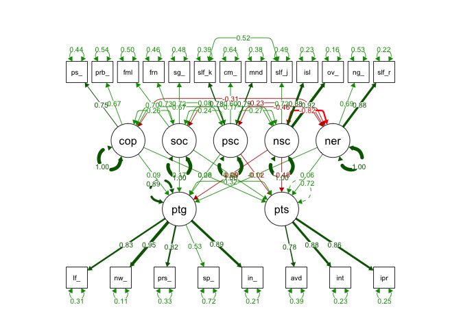

```r
semPaths(
  fit6,
  "std",
  edge.label.cex = 0.75,
  curvePivot = TRUE,
  title = TRUE,
  fade = FALSE
)
```

```r
lavaan::standardizedSolution(fit6) %>%
  dplyr::filter(!is.na(pvalue)) %>%
  arrange(desc(pvalue)) %>%
  mutate_if("is.numeric","round",3) %>%
  select(-ci.lower,-ci.upper,-z)
```

```
##                            lhs op                         rhs est.std    se
## 1                         ptss  ~                         psc  -0.018 0.071
## 2                         ptss  ~                       neuro   0.056 0.113
## 3                         ptgr  ~                         nsc  -0.092 0.099
## 4                         ptgr  ~                       neuro   0.111 0.112
## 5                         ptss  ~                        cope   0.082 0.076
## 6                         ptgr  ~                        cope   0.092 0.081
## 7                         ptss  ~                         soc   0.054 0.045
## 8                         cope ~~                         nsc   0.080 0.047
## 9                         ptgr  ~                         psc   0.196 0.081
## 10                        ptgr  ~                         soc   0.168 0.046
## 11                         soc ~~                         nsc   0.170 0.043
## 12                         soc ~~                         psc   0.239 0.048
## 13                         soc ~~                       neuro  -0.234 0.047
## 14                        ptss  ~                         nsc  -0.483 0.096
```

[output cut: 119 more lines]

```
##   label   lhs edge  rhs         est         std group fixed par
## 1        cope   ~> ptss  0.09620023  0.08179732       FALSE  22
## 2         soc   ~> ptss  0.06292427  0.05350337       FALSE  23
## 3         psc   ~> ptss -0.02135513 -0.01815788       FALSE  25
## 4       neuro   ~> ptss  0.06554947  0.05573553       FALSE  26
## 5        cope   ~> ptgr  0.09711596  0.09164761       FALSE  27
## 6         nsc   ~> ptgr -0.09800560 -0.09248716       FALSE  29
## 7       neuro   ~> ptgr  0.11713362  0.11053813       FALSE  31
```

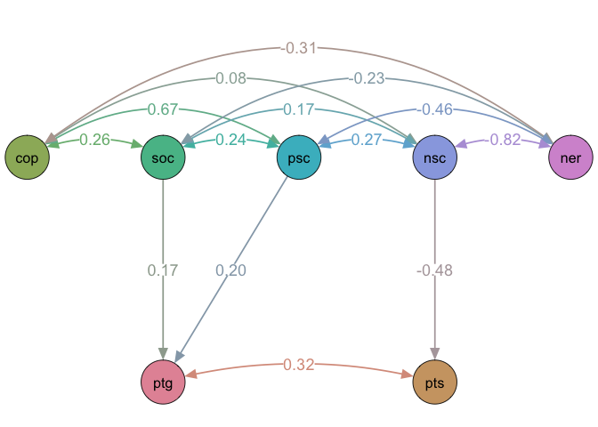

```r
pvalue_cutoff <- 0.05

obj <- semPlot:::semPlotModel(fit6)

# save a copy of the original, so we can compare it later and
#  be sure we removed only what we intended to remove
original_Pars <- obj@Pars

check_Pars <- obj@Pars %>%
  dplyr::filter(!(edge %in% c("int","<->") | lhs == rhs))
# this is the list of paramater to sift thru

keep_Pars <- obj@Pars %>%
  dplyr::filter(edge %in% c("int","<->") | lhs == rhs)
# this is the list of paramater to keep asis

test_against <- lavaan::standardizedSolution(fit6) %>%
  dplyr::filter(
    pvalue < pvalue_cutoff, rhs != lhs)

test_against_rev <- test_against %>%
  rename(rhs2 = lhs,
         lhs = rhs) %>%
  rename(rhs = rhs2)
# for some reason, the rhs and lhs are reversed in the
# standardizedSolution() output, for some of the values

checked_Pars <-
    check_Pars %>%
  semi_join(test_against, by = c("lhs", "rhs")) %>%
  bind_rows(
        check_Pars %>%
          semi_join(test_against_rev, by = c("lhs", "rhs"))
    )

# I'll have to reverse it myself, and test against both orders
obj@Pars <- keep_Pars %>%
  bind_rows(checked_Pars)

#let's verify by looking at the list of the edges we removed from the object
anti_join(original_Pars, obj@Pars)
```

```r
standardizedSolution(fit6) %>%
  dplyr::filter(op == "~" & (lhs == "ptss" | lhs == "ptgr")) %>%
  select(lhs, rhs, est.std, pvalue)
```

```
##     lhs   rhs est.std pvalue
## 1  ptss  cope   0.082  0.279
## 2  ptss   soc   0.054  0.236
## 3  ptss   nsc  -0.483  0.000
## 4  ptss   psc  -0.018  0.797
## 5  ptss neuro   0.056  0.623
## 6  ptgr  cope   0.092  0.257
## 7  ptgr   soc   0.168  0.000
## 8  ptgr   nsc  -0.092  0.348
## 9  ptgr   psc   0.196  0.015
## 10 ptgr neuro   0.111  0.324
```

# Model 7

Model 7 remove the two self-compassion regression effects from M6.

```r
model7 <- "

  # post-traumatic growth
  ptgr =~ life_appreciation + new_possibilities +
         personal_strength + spirituality_changes +
         interpersonal_relationships

  # ptss
  ptss =~ avoiding + intrusivity + iperarousal

  # coping
  cope =~ positive_attitude + problem_orientation

  # perceived social support
  soc =~ family + friends + significant_other

  # neuroticism
  neuro =~ negative_affect + self_reproach

  # self-compassion
  nsc =~ self_judgment + isolation + over_identification
  psc =~ self_kindness + common_humanity + mindfulness

  # regressions
  ptgr ~ cope + soc + neuro
  ptss ~ cope + soc + neuro

# covariances
  self_judgment ~~ self_kindness
"
```

```r
fit7 <- sem(
  model7,
  data = clean_dat,
  estimator = "MLM",
  std.lv = TRUE
)
```

```r
anova(fit6, fit7)
```

```
## Scaled Chi-Squared Difference Test (method = "satorra.bentler.2001")
##
## lavaan NOTE:
##     The "Chisq" column contains standard test statistics, not the
##     robust test that should be reported per model. A robust difference
##     test is a function of two standard (not robust) statistics.
##
##       Df   AIC   BIC  Chisq Chisq diff Df diff Pr(>Chisq)
## fit6 167 84671 84965 617.86
## fit7 171 84690 84965 644.98     24.859       4   5.37e-05 ***
## ---
## Signif. codes:  0 '***' 0.001 '**' 0.01 '*' 0.05 '.' 0.1 ' ' 1
```

M6 provides a better fit.

```
##        cfi cfi.robust        tli tli.robust      rmsea       srmr
##      0.943      0.945      0.930      0.932      0.062      0.060
```

# Model 8

M8 remove only the regression effect of the negative component of self-compassion from M6.

```r
model8 <- "

  # post-traumatic growth
  ptgr =~ life_appreciation + new_possibilities +
         personal_strength + spirituality_changes +
         interpersonal_relationships

  # ptsd
  ptss =~ avoiding + intrusivity + iperarousal

  # coping
  cope =~ positive_attitude + problem_orientation

  # perceived social support
  soc =~ family + friends + significant_other

  # self-compassion
  nsc =~ self_judgment + isolation + over_identification
  psc =~ self_kindness + common_humanity + mindfulness

  # neuroticism
  neuro =~ negative_affect + self_reproach

  # regressions
  ptgr ~ cope + soc + psc + neuro
  ptss ~ cope + soc + psc + neuro

  # covariances
  self_judgment ~~ self_kindness
"
```

```r
fit8 <- sem(
  model8,
  data = clean_dat,
  estimator = "MLM",
  std.lv = TRUE
)
```

The goodness of fit decreases.

```r
anova(fit6, fit8)
```

```
## Scaled Chi-Squared Difference Test (method = "satorra.bentler.2001")
##
## lavaan NOTE:
##     The "Chisq" column contains standard test statistics, not the
##     robust test that should be reported per model. A robust difference
##     test is a function of two standard (not robust) statistics.
##
##       Df   AIC   BIC  Chisq Chisq diff Df diff Pr(>Chisq)
## fit6 167 84671 84965 617.86
## fit8 169 84686 84971 637.59     19.693       2  5.292e-05 ***
## ---
## Signif. codes:  0 '***' 0.001 '**' 0.01 '*' 0.05 '.' 0.1 ' ' 1
```

```
##        cfi cfi.robust        tli tli.robust      rmsea       srmr
##      0.944      0.945      0.930      0.932      0.062      0.059
```

# Model 9

M9 removes only the positive component of self-compassion from M6.

```r
model9 <- "
  # post-traumatic growth
  ptgr =~ life_appreciation + new_possibilities +
         personal_strength + spirituality_changes +
         interpersonal_relationships

  # ptsd
  ptss =~ avoiding + intrusivity + iperarousal

  # coping
  cope =~ positive_attitude + problem_orientation

  # perceived social support
  soc =~ family + friends + significant_other

  # self-compassion
  nsc =~ self_judgment + isolation + over_identification
  psc =~ self_kindness + common_humanity + mindfulness

  # neuroticism
  neuro =~ negative_affect + self_reproach

  # regressions
  ptgr ~ cope + soc + nsc + neuro
  ptss ~ cope + soc + nsc + neuro

  # covariances
  self_judgment ~~ self_kindness
"
```

```r
fit9 <- sem(
  model9,
  data = clean_dat,
  estimator = "MLM",
  std.lv = TRUE
)
```

The goodness of fit decreases.

```r
anova(fit6, fit9)
```

```
## Scaled Chi-Squared Difference Test (method = "satorra.bentler.2001")
##
## lavaan NOTE:
##     The "Chisq" column contains standard test statistics, not the
##     robust test that should be reported per model. A robust difference
##     test is a function of two standard (not robust) statistics.
##
##       Df   AIC   BIC  Chisq Chisq diff Df diff Pr(>Chisq)
## fit6 167 84671 84965 617.86
## fit9 169 84674 84959 625.68     7.0747       2    0.02909 *
## ---
## Signif. codes:  0 '***' 0.001 '**' 0.01 '*' 0.05 '.' 0.1 ' ' 1
```